# Quantifying Allostatic Load

The Effects of Economic Status and Race on Health Outcomes in the United States

Author

Similoluwa Adefope, Emmy Napao & Comboni Tutu

**Abstract**

This research investigates the relationship between socioeconomic status, racial identity, and health outcomes in the United States, focusing on normal blood pressure and obesity as key indicators. Drawing on the framework of *allostatic load*, which describes the physiological wear and tear caused by chronic stress, this research highlights the disproportionate burden of health disparities on African Americans and individuals below the poverty line. Using data from the **IPUMS National Health Interview Survey (2001–2018)**, we employ regression analysis to examine how poverty and racial identity independently and interactively influence health outcomes, while controlling for confounding factors such as age, gender, region, and health-impacting behaviors.

**Summary Statistics**

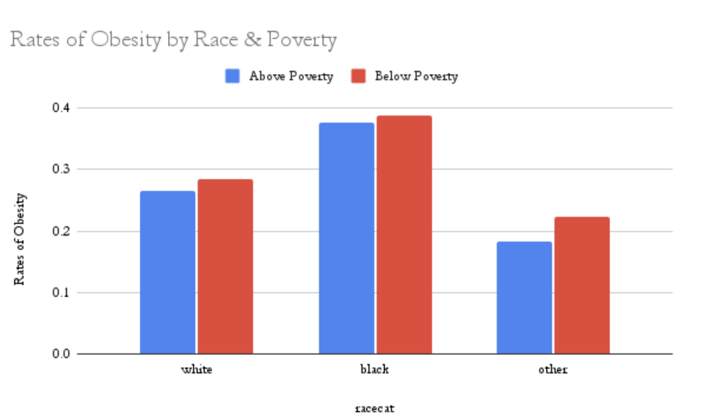

*Figure 1: The average rates of obesity across race categories and poverty levels from the years 2001 - 2018. (Blewett et al. 2024)*

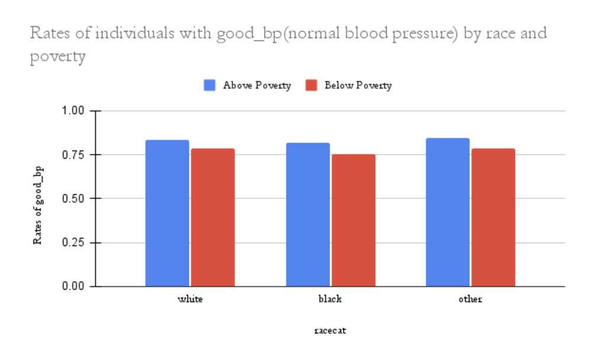

*Figure 2:The average rates of Normal Blood Pressure across race categories and socioeconomic class from the years 2003, 2001 - 2018. (Blewett et al. 2024)*

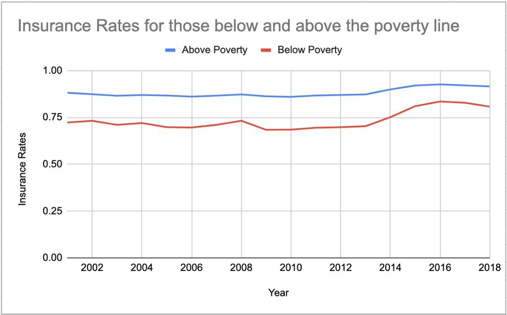

*Figure 3: Line graph showing trends over the years 2001 - 2018 of insurance rates for those below and above the poverty line in the United States (Blewett et al. 2024)*

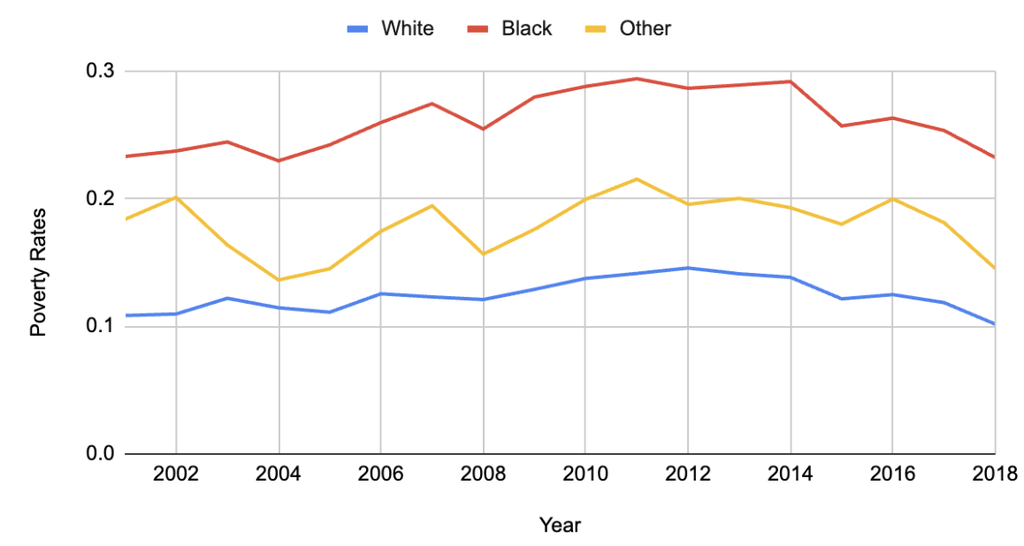

*Figure 4: Line graph showing trends over the years of poverty rates by race category from the years 2001 - 2018. (Blewett et al. 2024)*

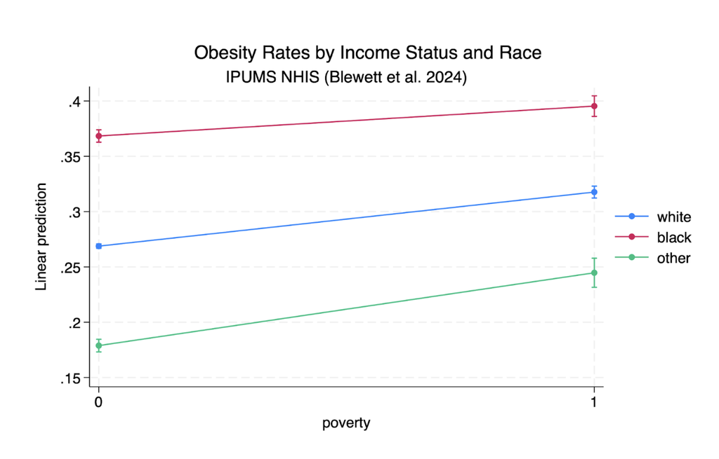

*Figure 5: This graph shows the linear prediction of the effects of being below the poverty line on the probability of being obese for each race category between the years 2001 - 2018 in the United States. (Blewett et al. 2024)*

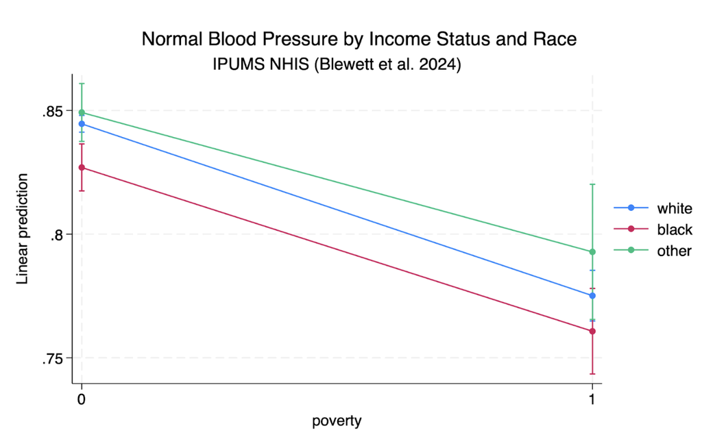

*Figure 6: This graph shows the linear prediction of the effects of being below the poverty line on the probability of having normal blood pressure for each race category between the years 2003, 2008, 2014, and 2017. (Blewett et al. 2024)*

**Description of Data and Sources**

For this research, we utilize data from the IPUMS Health Surveys: National Health Interview Survey (NHIS), specifically focusing on variables related to health outcomes, socioeconomic status, and demographic characteristics. This dataset provides comprehensive health-related data, allowing us to examine critical health metrics such as blood pressure and obesity while considering a wide range of confounding factors. Our analysis spans the years 2001 to 2018, covering over 500,000 observations, with specific subsamples for different health outcomes, such as normal blood pressure (107,625 observations) and obesity (513,652 observations).

**Results of Hypothesis Testing and Other Econometric Analysis**

*Normal Blood Pressure*

In running the naïve regression of good_bp (normal blood pressure) on poverty as seen in **Figure 6** , we find that 84% of those not in poverty regardless of race had a normal blood pressure and those in poverty were less likely to have a normal blood pressure by 5.1 percentage points meaning that they were 6% less likely to have a normal blood pressure. This difference in the probability of having a normal blood pressure reading was statistically significant at a 1% level with a p-value approximately equal to zero. In the naïve regression as seen in **Figure 6**, we found that Black people were the least likely to have normal blood pressure compared to the other two race categories. Black people within the sample were 2.6 percentage points less likely to have a normal blood pressure reading compared to their white counterparts within the sample meaning they were 3% less likely to have normal blood pressure. This difference in the probability of having a normal blood pressure reading was statistically significant at a 1% level with a p-value approximately equal to zero.

Running the regression with the interaction term for race categories and poverty, we see that being black and being poor had a statistically significant negative correlation with having a normal blood pressure. But the effect of being poor on being black was not statistically significant showing that although being black and being poor was a significant determinant for the probability of a person having abnormal blood pressure, the difference in the effect of being poor on those of African descent within the sample was not statistically significant. We think that an important thing to note is that although this interaction was not statistically significant, black people had the highest rates of poverty on average compared to other race categories as seen in **Figure 4** and with poverty being the larger determinant for health outcomes it shows that they would be the race category most inflicted with the negative cardiovascular health outcomes based on the data available to us.

*Obesity*

From our naive regression analysis of obesity rates across racial groups in **Figure 5**, approximately 26.9% of White individuals in our sample were classified as obese. The data reveals striking racial disparities, with Black individuals showing significantly higher obesity rates - specifically 10.2 percentage points higher than their White counterparts. To put this in perspective, Black individuals had about 38% higher probability of being obese compared to White individuals. This racial disparity was highly significant statistically at a 1% significance level.

In contrast, individuals classified in the “other races” category demonstrated notably lower obesity rates, being 8.37 percentage points less likely to be obese compared to White individuals. This translates to approximately 31% lower probability of obesity among this group relative to White individuals, with the difference being statistically significant at the 1% level.

When we consider how poverty correlates with these racial disparities as seen in **Figure 5**, we find that while Black individuals generally showed higher obesity rates, this racial gap slightly diminishes among those in poverty. Specifically, the difference in obesity probability between Black and White individuals decreases by 1.46 percentage points, approximately 3.84%, when comparing those below the poverty line to those above it. This interaction effect is statistically significant at the 5% level, suggesting that economic status moderates the relationship between race and obesity risk, particularly for Black individuals.

**Conclusion**

We believe that the cause of these negative health outcomes for those below the poverty line includes the lack of access to public amenities that foster better health outcomes such as public parks, well-funded public education, and low-cost access to fresh and healthy food. This lack of access leads to an increased difficulty for those within marginalized communities to make healthy choices combined with the easy accessibility to unhealthy choices such as fast food, nicotine, and alcohol.

More research is needed to discover if accessibility to healthy options is the root cause of the disparities we see in our results, but we believe they are a good enough reason to support policy changes such as funding public parks and walkways, increasing access to fresh food, and reducing access to unhealthy options for those in marginalized neighborhoods. We aim to motivate the introduction of laws that control these parameters of accessibility to bring about health equity within different socioeconomic classes and race categories.

**References**

- Blewett, Lynn A., Julia A. Rivera Drew, Miriam L. King, Kari C.W. Williams, Daniel Backman, Annie Chen, and Stephanie Richards. 2024. “IPUMS Health Surveys: National Health Interview Survey, Version 7.4.” Minneapolis, MN: IPUMS. https://doi.org/10.18128/D070.V7.4.
- “Racism and the Economy: Focus on Health | Federal Reserve Bank of Minneapolis.” n.d. Accessed December 10, 2024. https://www.minneapolisfed.org/events/2021/racism-and-the-economy-focus-on-health.